# MUM 2023-24 Modele auto-regresyjne

## szeregi czasowe

- wejście jest **uporządkowaną listą wektorów cech** (tokenów) $x_1,x_2,\dots,x_T$ z indeksem czasu $t$
- zakładaliśmy, że dane są IID, a więc niezależnie i identycznie próbkowane z tego samego rozkładu
  - teraz całe próbki (listy cech) wciąż są IID
  - jednak cechy wewnątrz próbki **nie są** IID
    - w przeciwnym przypadku nie miałoby sensu przetwarzać ich jako sekwencji!

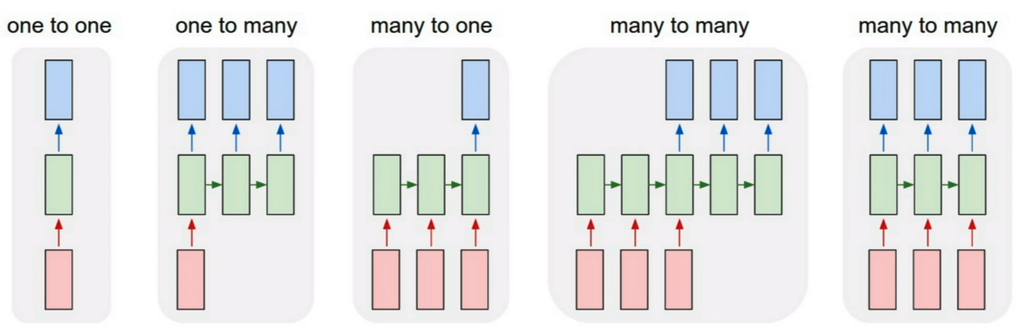

  - cele przetwarzania mogą być różne
  - klasyfikacja całej sekwencji, np. analiza sentymentu, [[generowanie obrazu z opisu]](https://huggingface.co/spaces/dalle-mini/dalle-mini) [[generowanie obrazu z opisu]](https://www.craiyon.com)
  - odwrotnie opisu obrazu, czyli z jednego do sekwencji
  - generowanie sekwencji na podstawie innej sekwencji, np. tłumaczenie
    - dopasowane (aligned) gdy celem jest zaznaczenie (tagging)
    - niedopasowane (non-aligned) gdy jest to maszynowe tłumaczenie

## modele auto-regresyjne

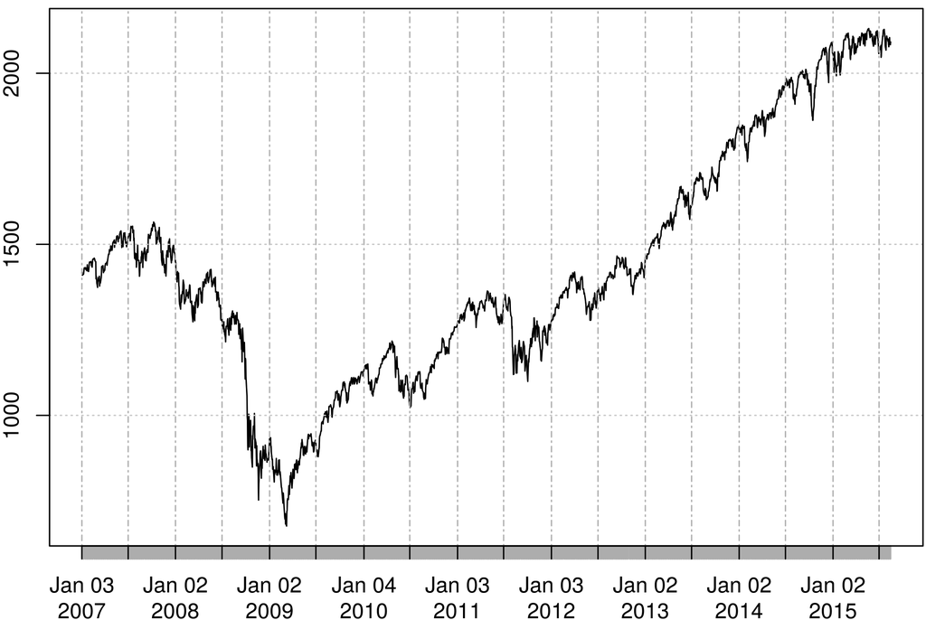

## uczenie sekwencji

- celem jest estymacja prawdopodobieństwa całkowitego dla całej sekwencji tokenów
  - modele sekwencji, modele językowe typowo NLP
  - estymacja likelihood sekwencji
  - modele językowe pozwalają także na samplowanie sekwencji, oraz optymalizację dla najbardziej prawdopodobnych sekwencji
- można zredukować problem językowy do problemu auto-regresywnego
  - dekompozycja prawdopodobieństwa całkowitego do **produktu** prawdopodobieństw warunkowych $$P(x_1,\dots,x_T)=P(x_1)\prod_{t=2}^TP(x_t\mid x_{t-1},\ldots,x_1)$$
  - dla sygnałów dyskretnych, ten model musi być klasyfikatorem generatywnym, zwracającym prawdopodobieństwa tokenów z całego słownika

### model Markowa

- w uczeniu jak wyżej wykorzystana jest wiedza z całej historii
- **własność Markowa** jest spełniona jeśli możliwe jest odrzucenie *części* tokenów z historii używając $x_{t-1},\dots,x_{t-\tau}$ zamiast $x_{t-1},\dots,x_1$
  - jeśli $\tau=1$, to dane są opisane przez **model Markowa pierwszego rzędu**
- dla modelu Markowa pierwszego rzędu faktoryzacja ma postać $$P(x_1,\dots,x_T)=P(x_1)\prod_{t=2}^TP(x_t\mid x_{t-1})$$
- bardzo często własność modelu Markowa pierwszego rzędu jest spełniona jedynie częściowo
  - zwykle wykorzystanie większej liczby poprzednich tokenów daje więcej informacji
  - jednak złożoność takiego rozwiązania bardzo szybko rośnie

### kierunek przetwarzania

- przetwarzanie od lewej do prawej, a nie odwrotnie, zwykle jest naturalne
- pozwala na estymację $$P(x_{t+1}, x_t,\dots,x_1)=P(x_t,\dots,x_1)\cdot{}P(x_t\mid x_{t-1},\dots,x_1)$$
- zwykle przyszłość nie ma wpływu na przeszłość

## uczenie auto-regresywne

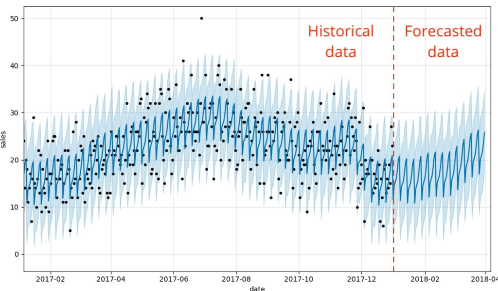

- założenie, że dane spełniają własność Markowa $\tau$-tego rzędu
  - model uczący wykorzystuje $\tau$ ostatnich wartości
  - uczona wartość $y=x_t$ dla $[x_{t-\tau},\dots,x_{t-1}]$
  - uczenie zwykłym modelem liniowym
  - cały zbiór uczący $[x_1,\dots,x_k]$ ma teraz $k-\tau$ próbek uczących

### predykcja

- predykcja dla $t<k$ będzie ok
- można przewidywać do $t=k+\tau$
- co jeśli potrzebna będzie predykcja $x_t$ dla $t=k+\tau+1$ czyli dla której **nie są jeszcze znane** wartości $x_{k+1}, x_{k+1},\dots,x_{k+\tau}$ na podstawie których ma być predykcja?
  - można wykorzystać predykcję **m kroków wprzód** wypełniając predykcjami m wartości aż do potrzebnej $$\begin{align} x_{k+\tau+1}&=f(x_{k+1}, x_{k+2},\dots,x_{k+\tau})\\ x_{k+\tau+2}&=f(x_{k+2}, x_{k+3},\dots,x_{k+\tau+1})\\ x_{k+\tau+3}&=f(x_{k+3}, x_{k+4},\dots,x_{k+\tau+2})\\ &\dots \end{align}$$
  - niestety predykcje algorytmów bardzo szybko odchodzą się od wartości prawdziwych
    - błędy się nawarstwiają
      - błąd dla pierwszego przewidywanego $k+\tau+1$ ma wartość $\epsilon_1=\epsilon$
      - dla kolejnego już $\epsilon_2=\epsilon+c\cdot\epsilon$ **i tak dalej**
  - im większe kroki predykcji wprzód, tym szybciej
  - to jak z prognozą pogody 😒